# PA1_template

Christine Arsenault

December 4, 2017

Question #1 Code for reading in the dataset and / or processing the data

First, add code for reading in the dataset and / or processing the data Then, subset data to remove NAs, calculate # of steps taken / day and add names to variables

```r
data <- read.csv(file="C:/Users/Songbird2015/documents/Coursera/Reproducible Research/activity.csv", header=T, sep=",", na.strings="NA")
cls = c("integer", "character", "integer")
names(data)
```

```
## [1] "steps"    "date"     "interval"
```

```r
str(data)
```

```
## 'data.frame':    17568 obs. of  3 variables:
##  $ steps   : int  NA NA NA NA NA NA NA NA NA NA ...
##  $ date    : Factor w/ 61 levels "2012-10-01","2012-10-02",..: 1 1 1 1 1 1 1 1 1 1 ...
##  $ interval: int  0 5 10 15 20 25 30 35 40 45 ...
```

```r
without_na <- data[complete.cases(data),]
total <- aggregate(steps ~ date, without_na, sum)
names(total)[2] <- "sum_steps"
```

Question #2 Create Histogram of the total number of steps taken each day

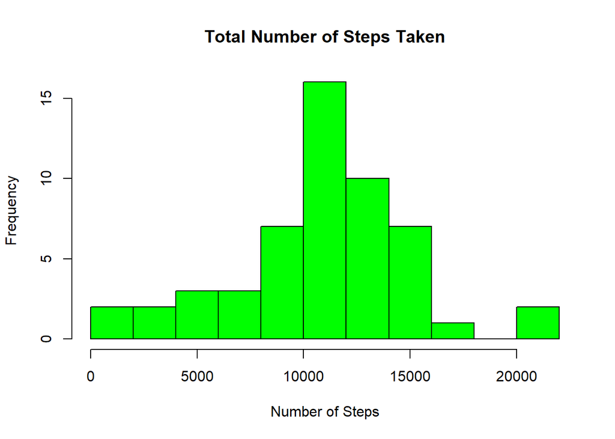

```r
hist(
        total$sum_steps,
        col = "green",
        main = "Total Number of Steps Taken",
        xlab = "Number of Steps",
        breaks = 10
)
```

Question #3 Find the mean and median number of steps taken each day

```r
mean(total$sum_steps)
```

```
## [1] 10766.19
```

```r
median(total$sum_steps)
```

```
## [1] 10765
```

Question #4. Time series plot of the average number of steps taken

Create interval and add names

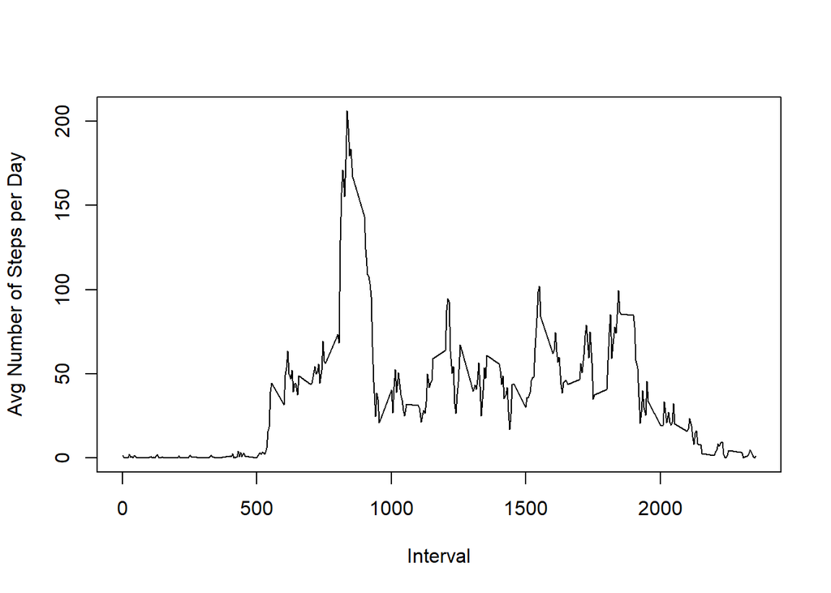

```r
steps_interval <- aggregate(steps ~ interval, data, mean, na.rm=TRUE)
mean_steps <- names(steps_interval)[2]
plot(steps_interval$interval, steps_interval$steps, type="l", xlab="Interval", ylab="Avg Number of Steps per Day")
```

Question #5 The 5-minute interval that, on average, contains the maximum number of steps

```r
max_value <- steps_interval[which.max(steps_interval$steps),1]
max_value
```

```
## [1] 835
```

Question #6 Code to describe and show a strategy for imputing missing data

Determine how many rows are missing data and create a new data frame

```r
nrow(data[is.na(data$steps),])
```

```
## [1] 2304
```

```r
imputed_data <- df
incomplete <- sum(!complete.cases(data))
imputed_data <- transform(data, steps = ifelse(is.na(data$steps), steps_interval$steps[match(data$interval, steps_interval$interval)], data$steps))
```

Plot Histogram

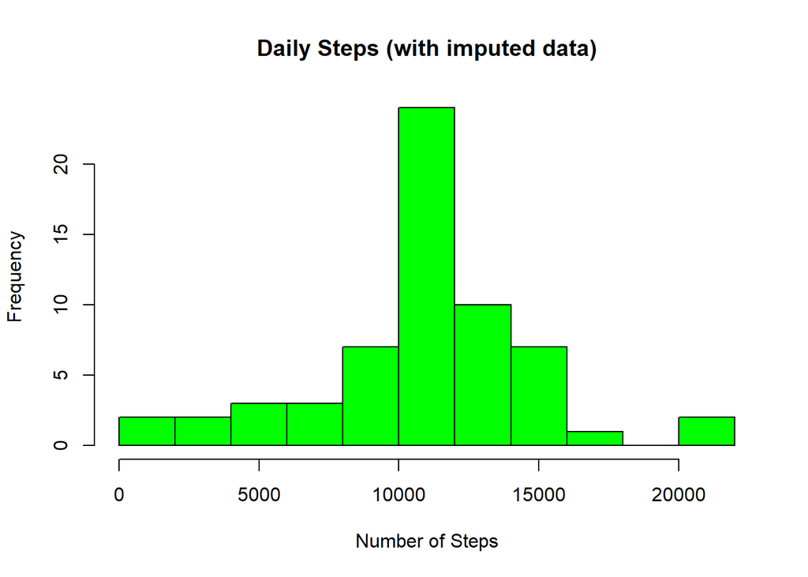

```r
new_daily <- tapply(imputed_data$steps, imputed_data$date, sum, na.rm=TRUE)
hist(x=new_daily,
     col="green",
     breaks=10,
     xlab="Number of Steps",
     ylab="Frequency",
     main="Daily Steps (with imputed data)")
```

Review new mean and median to determine if there are any differences

```r
mean(new_daily)
```

```
## [1] 10766.19
```

```r
median(new_daily)
```

```
## [1] 10766.19
```

Determine if a date falls on a weekday or weekend, convert type_of_day from character to factor, then calculate average steps by interval across all days

```r
imputed_data <- data
imputed_data['type_of_day'] <- weekdays(as.Date(imputed_data$date))
imputed_data$type_of_day[imputed_data$type_of_day  %in% c('Saturday','Sunday') ] <- "weekend"
imputed_data$type_of_day[imputed_data$type_of_day != "weekend"] <- "weekday"

imputed_data$type_of_day <- as.factor(imputed_data$type_of_day)

imputed_data_steps_by_interval <- aggregate(steps ~ interval + type_of_day, imputed_data, mean)
```

Question #8 Panel plot comparing the average number of steps taken per 5-minutes interval across weekdays and weekends

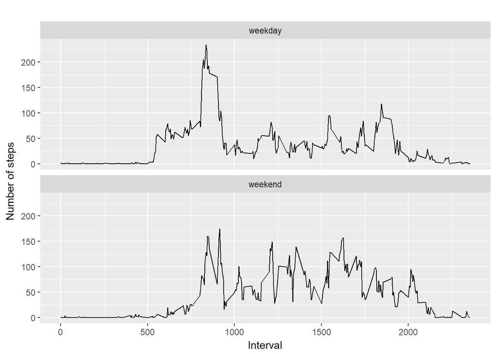

```r
library(ggplot2)
qplot(interval,
      steps,
      data = imputed_data_steps_by_interval,
      type = 'l',
      geom=c("line"),
      xlab = "Interval",
      ylab = "Number of steps",
      main = "") +
        facet_wrap(~ type_of_day, ncol = 1)
```